# Importing and Processing CSV Files

Leah Ho-Israel

2/21/2017

# Importing CSV Files

First, we will import the CSV file. In most cases, we don’t need to preprocess the csv files. Use “file.choose” to find the folder path name.

# Checking the Data

Now we will check the data by plotting it.

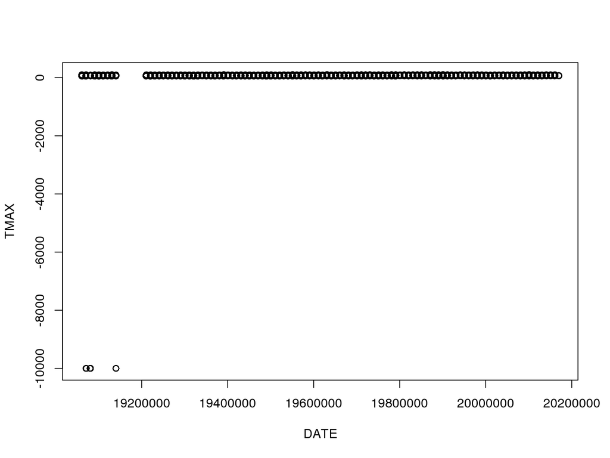

# Checking the Data

What’s going on? What is the deal with the -9999? These are used for missing data. We need to remove them!

Okay, now we’ll check again, for dates less then Dec. 31, 1913:

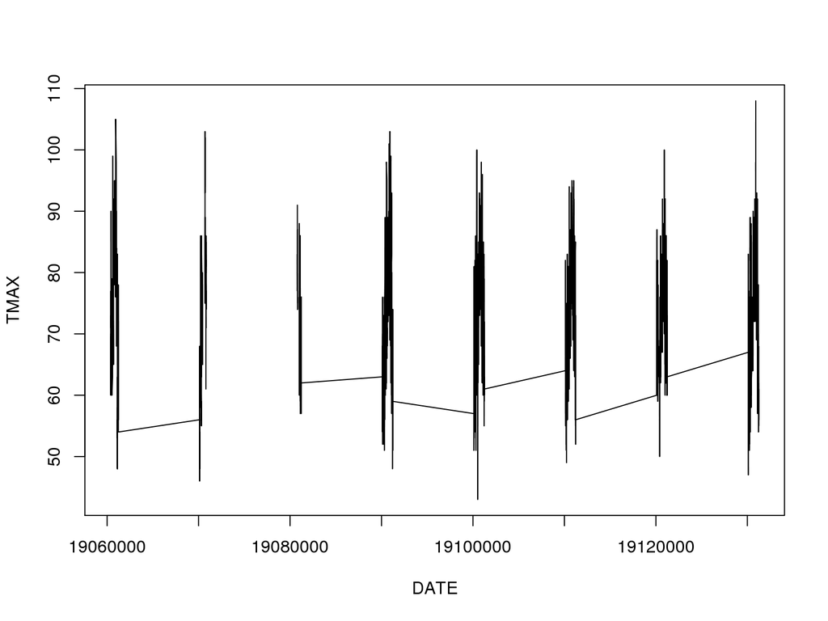

# Checking the Data

Yikes! What’s wrong? As it turns out the problem is that with how the dates are specified. In particular, the Dec 31 to Jan 1 transition:

19131231 -> 19140101, if you use these as numbers it should be 19131232, 19131232, etc. You see we are missing lots numbers!

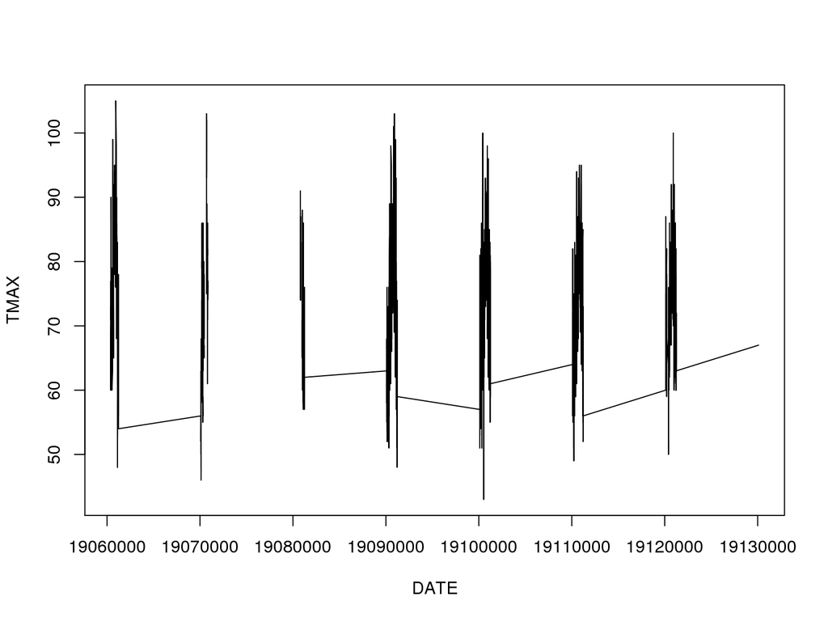

# Fixing the Dates

First, we convert the date to a string of character values. Next, we’ll convert the strings to a data format.

```
## [1] "19060401" "19060402" "19060403" "19060404" "19060405" "19060406"
```

# Checking the New Dates

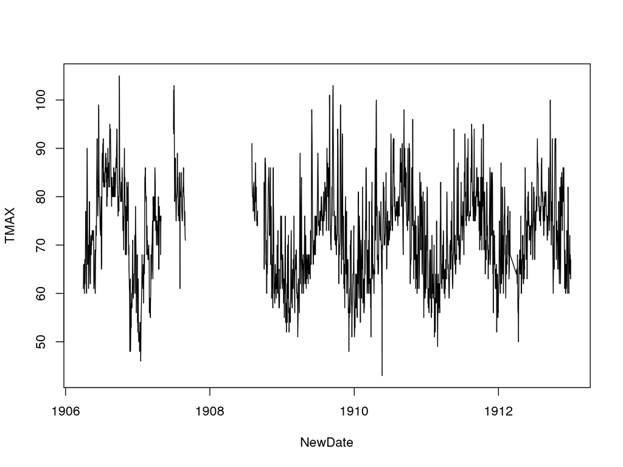

# Subset Sites

Olivia has two sites in here data, so, we need to subset it.

```
## [1] LOS ANGELES DOWNTOWN USC CA US
## Levels: LOS ANGELES DOWNTOWN USC CA US
```

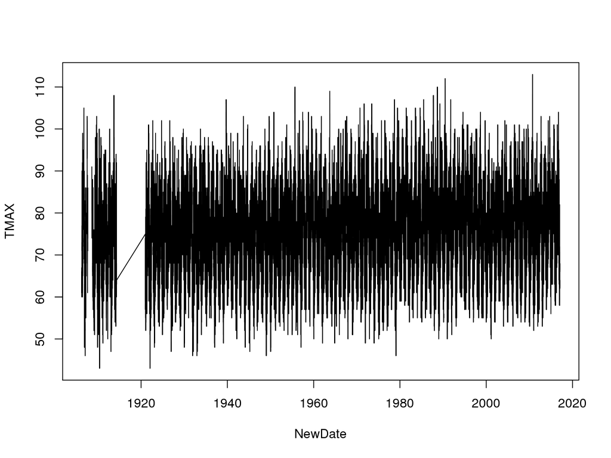

# Evaluating the trend

Creating a linear model and then evaluate the rate (slope).

```
##
## Call:
## lm(formula = TMAX ~ NewDate, data = LosAngeles)
##
## Residuals:
##     Min      1Q  Median      3Q     Max
## -29.746  -7.059  -0.072   6.601  37.001
##
## Coefficients:
##              Estimate Std. Error t value Pr(>|t|)
## (Intercept) 7.450e+01  4.900e-02 1520.36   <2e-16 ***
## NewDate     1.005e-04  4.348e-06   23.11   <2e-16 ***
## ---
## Signif. codes:  0 '***' 0.001 '**' 0.01 '*' 0.05 '.' 0.1 ' ' 1
##
## Residual standard error: 9.381 on 37564 degrees of freedom
##   (262 observations deleted due to missingness)
## Multiple R-squared:  0.01402,    Adjusted R-squared:  0.01399
## F-statistic: 533.9 on 1 and 37564 DF,  p-value: < 2.2e-16
```

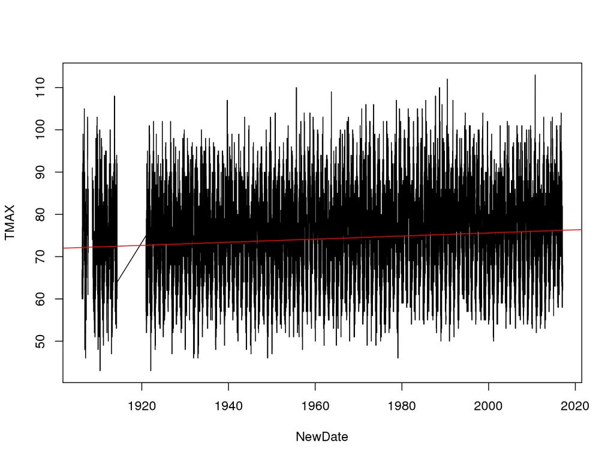

# Creating Month and Year Variables

So, let’s figure out how to see how changes happen for individual months.

# Creating Monthly Means

[output not shown]

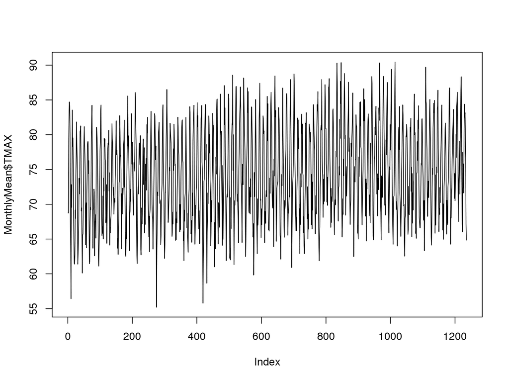

# Below is Standard Deviation

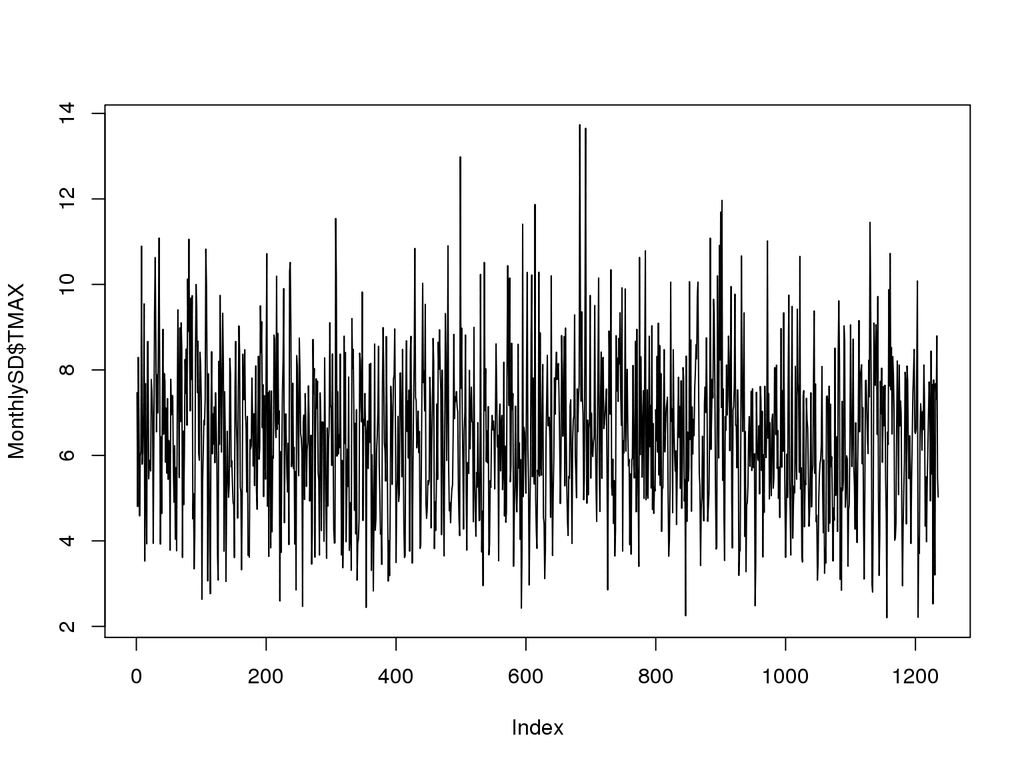

```
##
## Call:
## lm(formula = TMAX ~ NewDate, data = MonthlySD)
##
## Residuals:
##     Min      1Q  Median      3Q     Max
## -4.1774 -1.2691  0.0023  1.1882  7.2777
##
## Coefficients:
##              Estimate Std. Error t value Pr(>|t|)
## (Intercept) 11.220978   3.352130   3.347  0.00084 ***
## NewDate     -0.002416   0.001706  -1.416  0.15690
## ---
## Signif. codes:  0 '***' 0.001 '**' 0.01 '*' 0.05 '.' 0.1 ' ' 1
##
## Residual standard error: 1.828 on 1233 degrees of freedom
## Multiple R-squared:  0.001625,   Adjusted R-squared:  0.0008148
## F-statistic: 2.006 on 1 and 1233 DF,  p-value: 0.1569
```

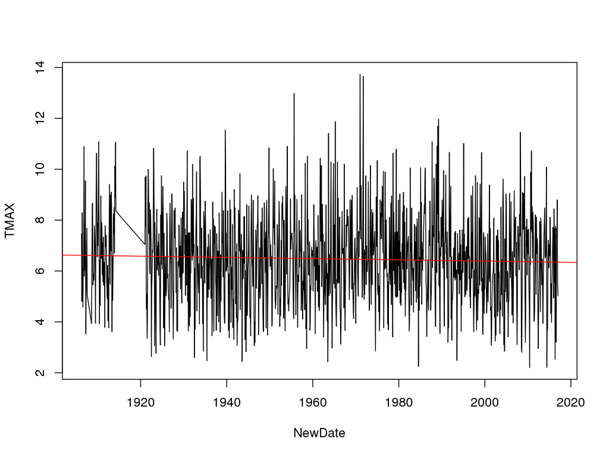

# Selecting for 1 Month – May

Perhaps, we can get a better handle on this stuff if we analyze for just one month at a time – certainly easier to visualize!

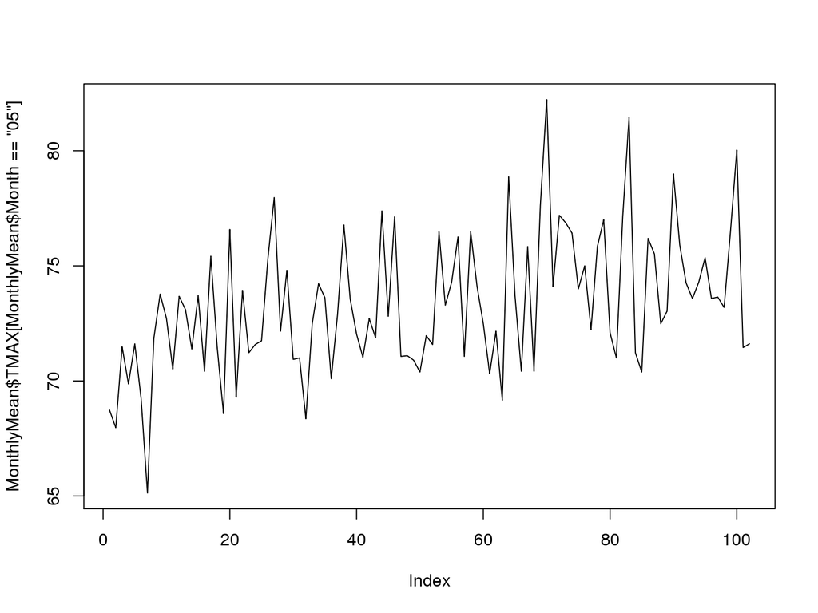

```
##
## Call:
## lm(formula = TMAX ~ YEAR, data = MonthlyMean[MonthlyMean$Month ==
##     "05", ])
##
## Residuals:
##     Min      1Q  Median      3Q     Max
## -6.3209 -1.8855 -0.2348  1.8522  8.1128
##
## Coefficients:
##              Estimate Std. Error t value Pr(>|t|)
## (Intercept) -9.753121  17.458611  -0.559    0.578
## YEAR         0.042271   0.008883   4.758 6.58e-06 ***
## ---
## Signif. codes:  0 '***' 0.001 '**' 0.01 '*' 0.05 '.' 0.1 ' ' 1
##
## Residual standard error: 2.709 on 100 degrees of freedom
## Multiple R-squared:  0.1846, Adjusted R-squared:  0.1765
## F-statistic: 22.64 on 1 and 100 DF,  p-value: 6.584e-06
```

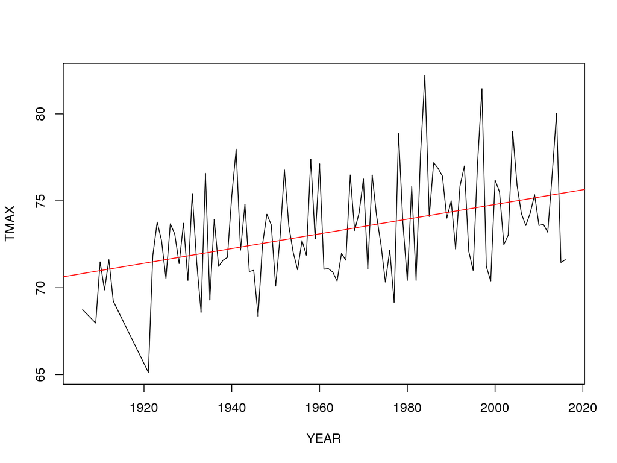

# Next Steps

I think you should evaluate every month and see what happens. You might also consider looking at the TMIN as well. Could be important!

# Lets try Dec

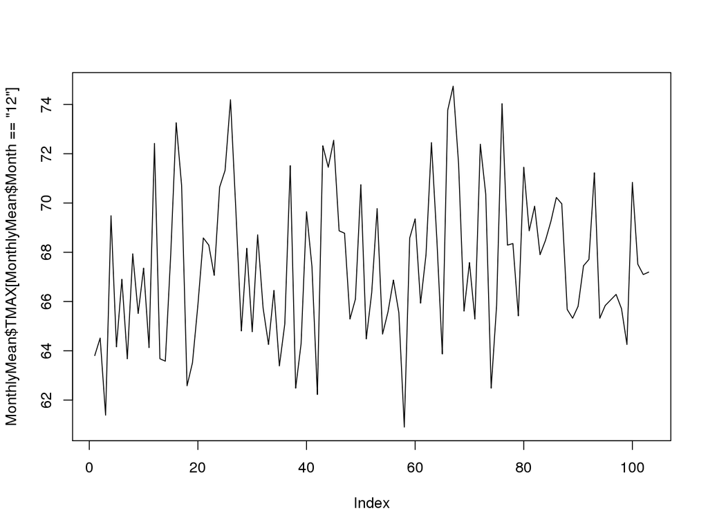

```
##
## Call:
## lm(formula = TMAX ~ YEAR, data = MonthlyMean[MonthlyMean$Month ==
##     "12", ])
##
## Residuals:
##     Min      1Q  Median      3Q     Max
## -6.6678 -2.3612 -0.4053  2.0698  7.1345
##
## Coefficients:
##              Estimate Std. Error t value Pr(>|t|)
## (Intercept) 36.039536  19.615565   1.837   0.0691 .
## YEAR         0.015998   0.009984   1.602   0.1122
## ---
## Signif. codes:  0 '***' 0.001 '**' 0.01 '*' 0.05 '.' 0.1 ' ' 1
##
## Residual standard error: 3.096 on 101 degrees of freedom
## Multiple R-squared:  0.02479,    Adjusted R-squared:  0.01514
## F-statistic: 2.568 on 1 and 101 DF,  p-value: 0.1122
```

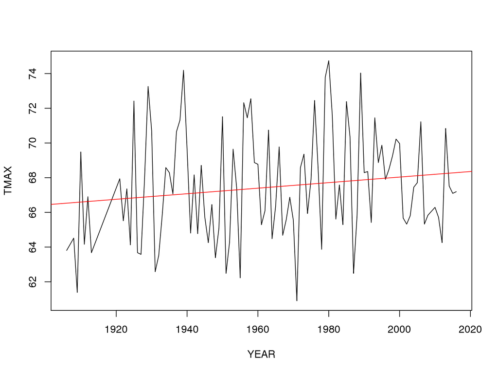

# TMIN

1. We create a monthly mean for each month.

```
##   Month Year     TMIN YEAR
## 1    04 1906 55.56667 1906
## 2    05 1906 57.41935 1906
## 3    06 1906 64.50000 1906
## 4    07 1906 70.19355 1906
## 5    08 1906 67.45161 1906
## 6    09 1906 64.16667 1906
```

# TMIN

2. Now we plot the mins, and again, find tons of scatter.

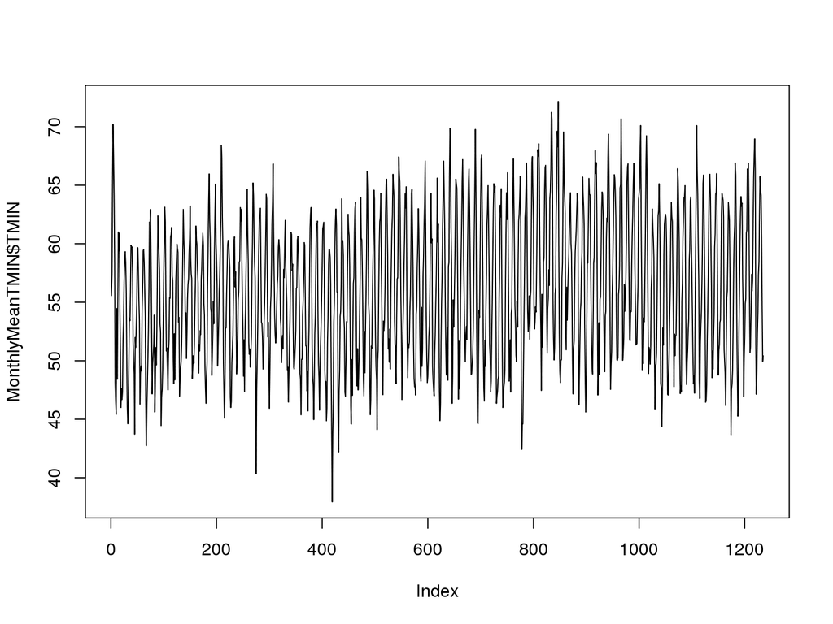

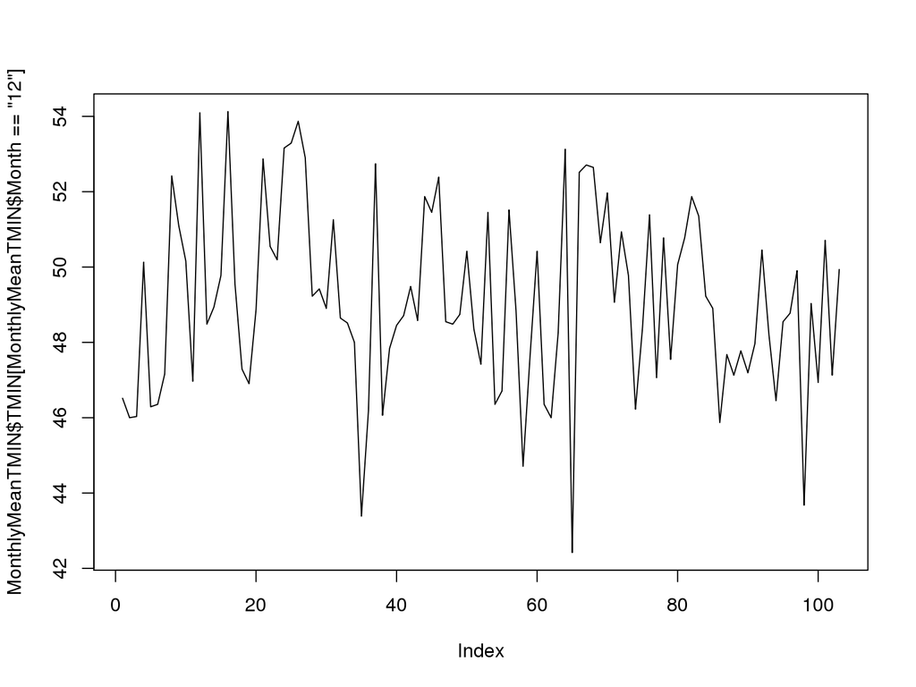

```
##
## Call:
## lm(formula = TMIN ~ YEAR, data = MonthlyMeanTMIN[MonthlyMeanTMIN$Month ==
##     "12", ])
##
## Residuals:
##     Min      1Q  Median      3Q     Max
## -6.5962 -1.6681 -0.2622  1.8577  4.7786
##
## Coefficients:
##              Estimate Std. Error t value Pr(>|t|)
## (Intercept) 62.531520  15.519733   4.029 0.000109 ***
## YEAR        -0.006833   0.007899  -0.865 0.389059
## ---
## Signif. codes:  0 '***' 0.001 '**' 0.01 '*' 0.05 '.' 0.1 ' ' 1
##
## Residual standard error: 2.45 on 101 degrees of freedom
## Multiple R-squared:  0.007355,   Adjusted R-squared:  -0.002474
## F-statistic: 0.7483 on 1 and 101 DF,  p-value: 0.3891
```

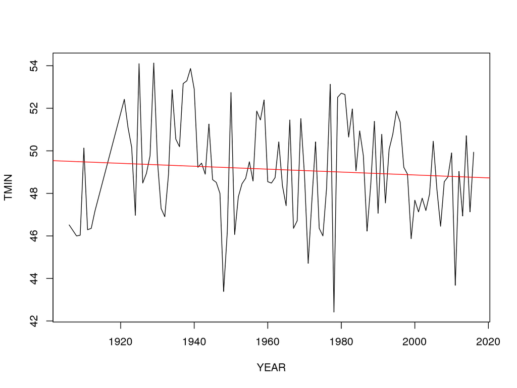

# TMIN

# Departure from Mean

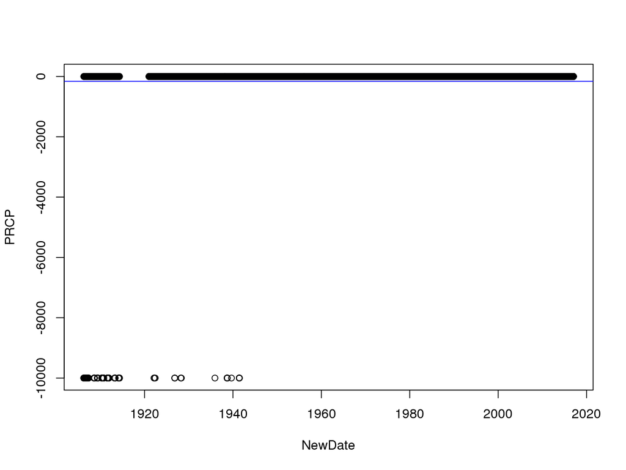

# Experimental Portion — Precipitation

Precipiation might depend more on the departure from the mean (often referred as as normal, whatever that means!). I think it’s worth pursuing, but haven’t finished the analysis yet.

First, we need a “mean” – The IPCC uses 1961-1990 as a norm, I don’t know what is the standard for California, so we should look that up.

Second, we need to remove the missing values and evalaute which years have complete years. If you are missing rainy months, then the whole year should be thrown out – but what about partial years in the drought season?

Third, we will need to decide what level of aggredation – monthly, yearly, etc.

Fourth, in CA the water year starts in Oct 1. Should we follow the same convention?

# Precipitation

A yearly mean, based on the annual sum for the entire records. Not sure this is appropriate.

# Precipitation

Figure has points of the yearly sum of rainfall and the blue line mean. The greenline is the trend and red line is a five year running average, I think! I am still trying to understand what the code is doing.

```
## [1] 0.2 0.2 0.2 0.2 0.2
```

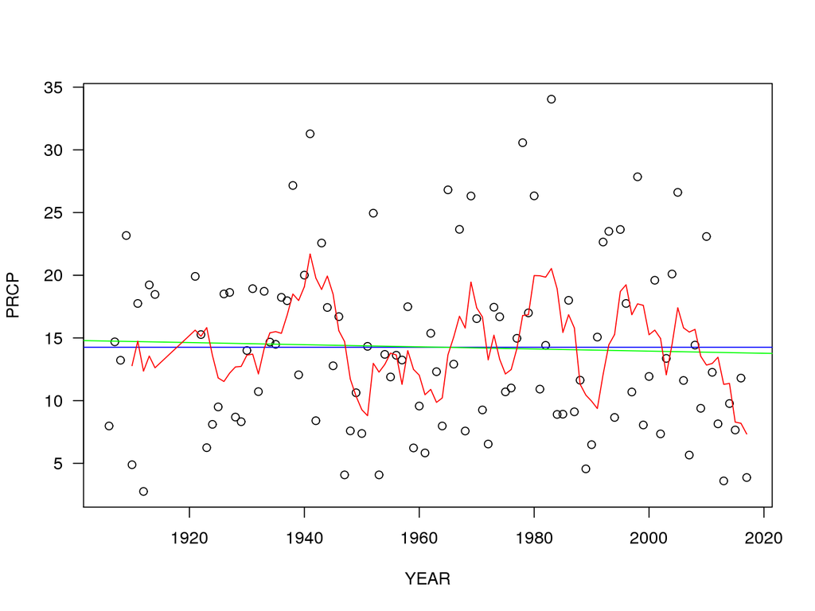

# Precipitation

The model suggests that the precipitation is declining at a rate of -0.0085364 cm yr$^{-1}~$, or -0.09 cm decade$^{-1}$.

```
##
## Call:
## lm(formula = PRCP ~ YEAR, data = YearlySum)
##
## Residuals:
##      Min       1Q   Median       3Q      Max
## -11.9403  -5.3017  -0.8905   3.8936  19.9458
##
## Coefficients:
##              Estimate Std. Error t value Pr(>|t|)
## (Intercept) 31.022016  41.868521   0.741     0.46
## YEAR        -0.008536   0.021315  -0.400     0.69
##
## Residual standard error: 6.9 on 104 degrees of freedom
## Multiple R-squared:  0.00154,    Adjusted R-squared:  -0.008061
## F-statistic: 0.1604 on 1 and 104 DF,  p-value: 0.6896
```